# Руководство пользователя Терминала

[(URL)](https://support.apple.com/ru-ru/guide/terminal/welcome/mac)

- Добро пожаловать!
- Что такое Терминал?
- Начало работы с Терминалом на Mac
- > Работа в окнах Терминала
  - Открытие и завершение приложения «Терминал»
  - Открытие новых окон и вкладок Терминала
  - Выполнение команд и запуск инструментов
  - Указание файлов и папок
  - Перенаправление ввода и вывода Терминала
  - Исправление опечаток
  - Перетягивание объектов в окно Терминала
  - Использование групп окон
- > Индивидуальная настройка Терминала
  - Изменение настроек
  - Использование профилей для изменения внешнего вида окон Терминала
  - Выбор профиля по умолчанию и загрузочного профиля окна Терминала
  - Настройка звуковых и визуальных предупреждений
  - Ограничение количества строк в буфере прокрутки
  - Импорт и экспорт профилей Терминала
- > Использование автоматизации задач и скриптов
  - Основные сведения o shell-скриптах
  - Превращение файла в исполняемый файл
  - Управление скриптами с помощью команды launchd
  - Автоматизация задач с помощью AppleScript и Терминала
- Сочетания клавиш
- Авторские права

# Что такое Терминал на Mac?

[(URL)](https://support.apple.com/ru-ru/guide/terminal/trmld4c92d55/mac)

Терминал — это приложение для опытных пользователей и разработчиков, которое дает возможность взаимодействовать с операционной системой Mac через интерфейс командной строки. В Терминале можно вводить команды и скрипты (так называемые shell-скрипты) для выполнения задач на Mac.

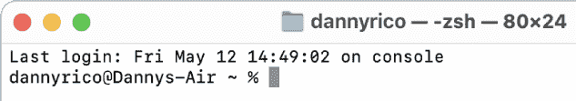

При открытии Терминала отображается простое окно с приглашением в командную строку. В Терминале доступен широкий выбор команд и параметров, которые можно использовать для выполнения любых задач: от простых до очень сложных. Подробнее об отображении и использовании команд в Терминале см. в статье Чтение справочных страниц UNIX (на английском языке) на сайте Apple для разработчиков.

В отличие от обычных приложений Mac, где используется графический интерфейс — кнопки, бегунки и меню, — в Терминале для выполнения задач и доступа к функциям нужно вводить код в интерфейсе командной строки. Такие команды (и последовательности команд, отправляемые в виде скриптов) выполняются оболочкой (shell), которая представляет собой пользовательский интерфейс операционной системы UNIX.

В Терминале можно выполнять команды и скрипты, которые сообщают оболочке (shell), что необходимо сделать. Например, с помощью команды можно показать содержимое папки или запустить скрипт, автоматизирующий открытие приложения и выполнение определенной задачи.

Также с помощью простых скриптов в Терминале можно экономить время и автоматизировать часто выполняемые задачи. Когда Вам требуется автоматизация задач или работа со скриптами на быстрых низкоуровневых языках программирования, Терминал предоставляет легкий доступ к вводу и выводу командных оболочек UNIX, в том числе BASH и ZSH.

Подробнее об использовании Терминала и создании скриптов см. в статье Основные сведения о shell-скриптах на сайте Apple для разработчиков.

Примечание. Приложение «Терминал» также может быть полезно при устранении проблем на Mac с помощью службы поддержки Apple. Рекомендуется не удалять это приложение с компьютера.

См. также

[Выполнение команд и запуск инструментов в приложении «Терминал» на Mac](https://support.apple.com/ru-ru/guide/terminal/apdb66b5242-0d18-49fc-9c47-a2498b7c91d5/2.14/mac/15.0)

[Сочетания клавиш приложения «Терминал» на Mac](https://support.apple.com/ru-ru/guide/terminal/trmlshtcts/2.14/mac/15.0)

# Начало работы с Терминалом на Mac

[(URL)](https://support.apple.com/ru-ru/guide/terminal/pht23b129fed/mac)

Терминал — это приложение, позволяющее выполнять задачи с помощью интерфейса командной строки в macOS.

# Использование командной строки

С помощью командной строки в Терминале можно быстро выполнять команды, а также запускать инструменты и shell-скрипты. Например, чтобы просмотреть список файлов в папке по умолчанию, введите команду списка ls, а затем нажмите клавишу Return. По завершении очистите окно списка, выбрав меню «Правка» > «Очистить окно».

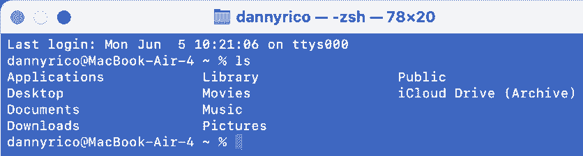

# Поиск нужных команд

Для поиска команд UNIX можно использовать команду man. Она отображает справочные страницы, называемые man‑страницами. Чтобы отобразить man‑страницу со сведениями о команде man, введите команду man man, затем нажмите клавишу Return. Чтобы закрыть man‑страницу и очистить окно, нажмите клавишу q.

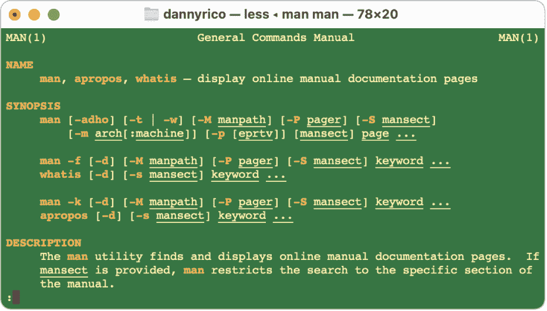

# Настройка окон Терминала

Можно изменить оформление окон Терминала, чтобы легко различать их, когда у Вас одновременно открыто несколько окон. Чтобы отобразить параметры окна, выберите меню «Терминал» > «Настройки», затем нажмите «Профили».

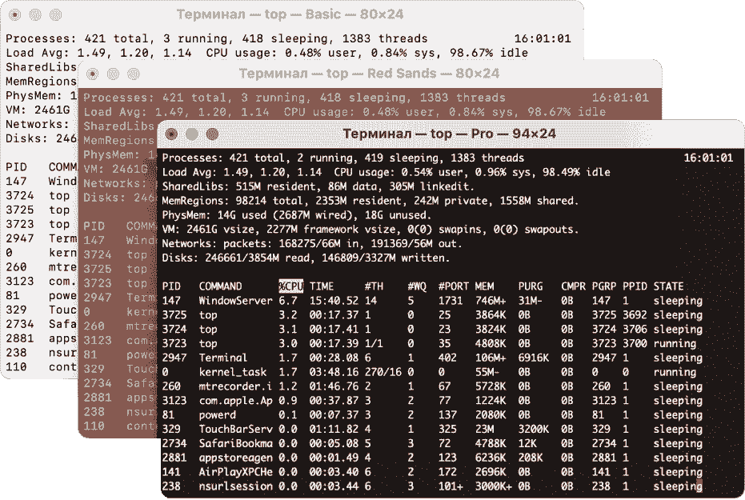

# Готовы создавать скрипты?

Если Вы только начинаете создавать скрипты, изучите страницу сайта Apple для разработчиков: Основные сведения о shell-скриптах. На ней можно узнать больше о работе с shell-скриптами в приложении «Терминал».

```
export PATH="/usr/local/bin:$PATH"

# or

PATH="/usr/local/bin:$PATH"
export PATH
```

# Хотите узнать больше?

[Использование профилей для изменения внешнего вида окон Терминала](https://support.apple.com/ru-ru/guide/terminal/trml107/2.14/mac/15.0)

[Сайт Apple для разработчиков: Чтение справочных страниц UNIX (на английском языке)](https://developer.apple.com/documentation/os/reading_unix_manual_pages)

[Управление файлами в Терминале](https://support.apple.com/ru-ru/guide/terminal/apddfb31307-3e90-432f-8aa7-7cbc05db27f7/2.14/mac/15.0%7C)

# Работа в окнах Терминала

- Работа в окнах Терминала
  - Открытие и завершение приложения «Терминал»
  - Открытие новых окон и вкладок Терминала
  - Выполнение команд и запуск инструментов
  - Указание файлов и папок
  - Перенаправление ввода и вывода Терминала
  - Исправление опечаток
  - Перетягивание объектов в окно Терминала
  - Использование групп окон

# Открытие и завершение приложения «Терминал» на Mac

[(URL)](https://support.apple.com/ru-ru/guide/terminal/apd5265185d-f365-44cb-8b09-71a064a42125/mac)

В приложении «Терминал» можно управлять macOS с помощью интерфейса командной строки. Каждое окно в Терминале представляет свой экземпляр процесса shell. Окно содержит приглашение, которое означает, что можно вводить команду. Отображаемое приглашение зависит от настроек Терминала и shell, однако обычно оно включает имя хоста, к которому Вы подключены, Вашу текущую рабочую папку, Ваше имя пользователя и символ приглашения. Например, если пользователь с именем michael использует по умолчанию оболочку zsh, приглашение выглядит следующим образом:

```
michael@MacBook-Pro ~ %
```

В приглашении указано, что пользователь с именем michael вошел в систему на компьютере с именем MacBook-Pro и текущей папкой является его папка пользователя, обозначаемая тильдой (~).

# Открытие Терминала

На компьютере Mac выполните одно из следующих действий.

- Нажмите значок Launchpad в панели Dock, введите «Терминал» в поле поиска и нажмите значок Терминала.
- В окне Finder откройте папку «Программы/Утилиты» и дважды нажмите приложение «Терминал». В открытом окне Терминала можно выполнять команды и запускать инструменты.

# Завершение приложения «Терминал»

Откройте приложение «Терминал» на Mac. Выберите «Терминал» > «Завершить Терминал».

# Завершение сеанса shell

Откройте приложение «Терминал» на Mac. В окне с запущенным процессом shell, который Вы хотите завершить, введите exit и нажмите клавишу Return. Это обеспечит закрытие всех текущих команд, выполняемых в shell. Если что-то продолжает выполняться, появляется диалоговое окно. Если Вы хотите изменить поведение приложения при выходе из shell, см. Изменение настроек shell для профилей.

См. также

[Изменение оболочки shell по умолчанию в Терминале на Mac](https://support.apple.com/ru-ru/guide/terminal/trml113/2.14/mac/15.0)

[Открытие новых окон и вкладок Терминала на Mac](https://support.apple.com/ru-ru/guide/terminal/trmlb20c7888/2.14/mac/15.0)

[Использование профилей для изменения внешнего вида окон Терминала на Mac](https://support.apple.com/ru-ru/guide/terminal/trml107/2.14/mac/15.0)

[Сайт Apple для разработчиков: Основные сведения о командной строке (на английском языке)](https://developer.apple.com/library/content/documentation/OpenSource/Conceptual/ShellScripting/CommandLInePrimer/CommandLine.html)

# Открытие новых окон и вкладок Терминала на Mac

[(URL)](https://support.apple.com/ru-ru/guide/terminal/trmlb20c7888/mac)

При открытии новых окон и вкладок Терминала может использоваться профиль по умолчанию, профиль активного окна или вкладки, а также выбранный Вами профиль. В разделе настроек «Основные» можно выбрать профили, которые будут использоваться при открытии новых окон и вкладок. Если Вы не выбрали профиль по умолчанию, используется профиль Basic (см. Выбор профиля по умолчанию и загрузочного профиля окна Терминала)

# Открытие новых окон Терминала с профилем по умолчанию или с тем же профилем, который используется в активном окне

Открываемый профиль (профиль по умолчанию или тот же профиль, который используется в активном окне) зависит от значения параметра «В новых окнах открывать» в разделе настроек «Основные».

- Откройте приложение «Терминал» на Mac.
- Выполните одно из следующих действий.
  - Нажмите сочетание клавиш Command-N.
  - Выберите пункт меню «Shell» > «Новое окно» > «Новое окно с профилем». Имя открываемого профиля добавляется к пункту «Новое окно» в меню «Профиль».

# Открытие новых окон Терминала с выбранным профилем

- Откройте приложение «Терминал» на Mac.
- Выполните одно из следующих действий.
  - Выберите «Shell» > «Новое окно», затем выберите профиль из списка профилей в конце меню.
  - Выберите «Терминал» > «Настройки», затем нажмите «Профили». В списке профилей дважды нажмите значок профиля, который хотите использовать.

# Открытие новых вкладок с профилем по умолчанию или с тем же профилем, который используется в активной вкладке

Открываемый профиль (профиль по умолчанию или тот же профиль, который используется в активной вкладке) зависит от значения параметра «В новых вкладках открывать» в разделе настроек «Основные».

- Откройте приложение «Терминал» на Mac.
- Выполните одно из следующих действий.
  - Нажмите сочетание клавиш Command-T.
  - Выберите пункт меню «Shell» > «Новая вкладка» > «Новая вкладка с профилем». Имя открываемого профиля добавляется к пункту «Новая вкладка» в меню «Профиль».

# Открытие новых вкладок с выбранным профилем

- Откройте приложение «Терминал» на Mac.
- Выберите «Shell» > «Новая вкладка», затем выберите профиль из списка профилей в конце меню.

# Открытие новых окон или вкладок Терминала из Finder

Для открытия нового окна или вкладки Терминала можно использовать строку пути в окне Finder, указав расположение папки в качестве рабочей директории.

- На Mac откройте окно Finder, затем перейдите к папке, которую нужно использовать.
- Если строка пути не отображается в нижней части окна Finder, выберите «Вид» > «Показать строку пути».
- Нажмите папку в строке пути, удерживая клавишу Control, затем выполните любое из указанных ниже действий.
  - Открытие нового окна. Выберите «Открыть в Терминале».
  - Открытие новой вкладки. Выберите «Службы» > «Новая вкладка терминала по адресу папки».

См. также

[Использование профилей для изменения внешнего вида окон Терминала на Mac](https://support.apple.com/ru-ru/guide/terminal/trml107/2.14/mac/15.0)

[Выбор профиля по умолчанию и загрузочного профиля окна Терминала на Mac](https://support.apple.com/ru-ru/guide/terminal/trml5856b1f2/2.14/mac/15.0)

[Изменение настроек раздела «Основные» в Терминале на Mac](https://support.apple.com/ru-ru/guide/terminal/trmlstrtup/2.14/mac/15.0)

# Выполнение команд и запуск инструментов в приложении «Терминал» на Mac

[(URL)](https://support.apple.com/ru-ru/guide/terminal/apdb66b5242-0d18-49fc-9c47-a2498b7c91d5/mac)

Среду командной строки можно использовать в интерактивном режиме, то есть вводить команду и ждать результат. Вы также можете составить shell-скрипт, который будет выполняться без Вашего непосредственного участия. Для получения подробной информации о командах ознакомьтесь с документацией для низкоуровневых инструментов UNIX и API в приложении «Терминал». См. статью Чтение справочных страниц в UNIX (на английском языке) на веб‑сайте Apple для разработчиков.

# Выполнение команд в оболочке shell

Откройте приложение «Терминал» на Mac.

Введите полный путь к исполняемому файлу инструмента, затем введите все необходимые аргументы и нажмите клавишу Return.

Если команда находится в одной из известных папок shell, при вводе имени команды можно не указывать путь. Список известных папок хранится в переменной среды PATH оболочки shell и включает папки, содержащие большинство инструментов командной строки.

Например, чтобы выполнить команду ls в папке текущего пользователя, введите следующую команду в командной строке, затем нажмите Return:

```
% ls
```

Чтобы выполнить команду в папке текущего пользователя, введите перед командой спецификатор папки. Например, чтобы выполнить MyCommandLineProg, используйте следующую команду:

```
% ~/MyCommandLineProg
```

Чтобы открыть приложение, используйте команду open:

```
% open -a MyProg.app
```

Если при вводе команды отображается сообщение command not found, проверьте правильность написания. Пример:

```
% opne -a TextEdit.app
zsh: opne: command not found
```

Другие доступные команды см. на сайте Apple для разработчиков в разделе [Основные сведения о командной строке (на английском языке)](https://developer.apple.com/library/content/documentation/OpenSource/Conceptual/ShellScripting/CommandLInePrimer/CommandLine.html).

# Прерывание команд

- Откройте приложение «Терминал» на Mac.
- Нажмите окно Терминала, где выполняется команда, которую Вы хотите завершить.
- Нажмите сочетание клавиш Control-C.

Будет отправлен сигнал, который вызывает прерывание большинства команд.

# Повтор ранее введенных команд

Введенные в текущем сеансе команды сохраняются, так что Вы можете повторить ранее использованную команду, не вводя ее снова.

- Откройте приложение «Терминал» на Mac.
- Нажать клавишу со стрелкой вверх.

Последняя введенная команда отобразится в командной строке.

- Продолжайте нажимать клавишу со стрелкой вверх, пока не появится нужная команда, затем нажмите клавишу Return.

См. также

[Выбор файлов и папок в приложении «Терминал» на Mac](https://support.apple.com/ru-ru/guide/terminal/apd3cf6fe02-3ec8-48f1-951f-866e52955fc8/2.14/mac/15.0)

[Перенаправление ввода и вывода в приложении «Терминал» на Mac](https://support.apple.com/ru-ru/guide/terminal/apd1dbe647b-7e11-49dc-aa76-89aa7e53ce36/2.14/mac/15.0)

[Перетягивание объектов в окно Терминала на Mac](https://support.apple.com/ru-ru/guide/terminal/trml106/2.14/mac/15.0)

[Сочетания клавиш приложения «Терминал» на Mac](https://support.apple.com/ru-ru/guide/terminal/trmlshtcts/2.14/mac/15.0)

# Выбор файлов и папок в приложении «Терминал» на Mac

[(URL)](https://support.apple.com/ru-ru/guide/terminal/apd3cf6fe02-3ec8-48f1-951f-866e52955fc8/mac)

Большинство команд работает с файлами и папками, местонахождение которых задается с помощью путей. Имена папок, из которых состоит путь, разделяются с помощью косой черты. Например, путь к приложению «Терминал» имеет следующий вид: /Программы/Утилиты/Terminal.app.

В следующей таблице показаны стандартные сокращения, используемые для обозначения определенных папок. Сокращения задают пути относительно текущей папки, устраняя необходимость ввода полных путей.

[output not shown]

Имена файлов и папок могут включать буквы и цифры, а также точку и символ подчеркивания. Не используйте другие символы, например пробелы. Несмотря на то что некоторые файловые системы разрешают использование других символов, включая пробелы, в этом случае вокруг путей может потребоваться добавлять одинарные или двойные кавычки.

Отдельный символ можно интерпретировать буквально, то есть добавить управляющий символ (escape-символ) обратной косой черты непосредственно перед символом в строке. Например, имя пути My Disk задается как «My Disk» или My\ Disk.

См. также

[Выполнение команд и запуск инструментов в приложении «Терминал» на Mac](https://support.apple.com/ru-ru/guide/terminal/apdb66b5242-0d18-49fc-9c47-a2498b7c91d5/2.14/mac/15.0)

[Перенаправление ввода и вывода в приложении «Терминал» на Mac](https://support.apple.com/ru-ru/guide/terminal/apd1dbe647b-7e11-49dc-aa76-89aa7e53ce36/2.14/mac/15.0)

[Статья на веб-сайте Apple для разработчиков: основные сведения о командной строке (на английском языке)](https://developer.apple.com/library/content/documentation/OpenSource/Conceptual/ShellScripting/CommandLInePrimer/CommandLine.html)

# Перенаправление ввода и вывода в приложении «Терминал» на Mac

[(URL)](https://support.apple.com/ru-ru/guide/terminal/apd1dbe647b-7e11-49dc-aa76-89aa7e53ce36/mac)

С помощью командной строки можно перенаправлять потоки входных и выходных данных с команды на файл или другую команду.

Перенаправьте вывод из команды, если хотите сохранить результаты выполнения команды в файле для дальнейшего использования. Перенаправьте ввод команды на получение готовых данных из файла, если не хотите вводить входные данные вручную.

Для перенаправления ввода и вывода используются следующие символы:

| Перенаправление | Описание |
| --- | --- |
| > | Используйте правую угловую скобку, чтобы перенаправить выходные данные команды в файл. |
| < | Используйте левую угловую скобку, чтобы использовать содержимое файла в качестве входных данных команды. |
| >> | Используйте две правые угловые скобки, чтобы добавить вывод из команды в файл. |

Помимо перенаправления в файл и из файла, Вы можете перенаправить выходные данные одной команды на вход другой команды с помощью символа вертикальной черты или потока. Таким образом команды можно комбинировать для получения более сложных версий тех же команд.

Например, следующая команда передает отформатированное содержимое man-страницы zsh инструменту grep, который ищет в этих данных строки, содержащие слово commands. Результатом является список строк с заданным текстом, а не целая man-страница.

```
% man zsh | grep commands
```

Стандартные потоки ввода/вывода:

- stdin. Стандартный поток ввода — это поток, из которого команда получает входные данные. По умолчанию входные данные вводятся через интерфейс командной строки. Вы можете перенаправить вывод из файлов или других команд в поток stdin.
- stdout. Стандартный поток вывода — это поток, куда команда отправляет выходные данные. По умолчанию команда выводит данные в командную строку. Вы можете перенаправить вывод с командной строки на другие команды и инструменты.
- stderr. Стандартный поток ошибок — это поток, куда отправляются сообщения об ошибках. По умолчанию ошибки отображаются в командной строке вместе со стандартным потоком вывода.

Подробнее о перенаправлении см. на man-странице команды zsh.

```
man -P cat zsh
```

См. также

[Выполнение команд и запуск инструментов в приложении «Терминал» на Mac](https://support.apple.com/ru-ru/guide/terminal/apdb66b5242-0d18-49fc-9c47-a2498b7c91d5/2.14/mac/15.0)

[Выбор файлов и папок в приложении «Терминал» на Mac](https://support.apple.com/ru-ru/guide/terminal/apd3cf6fe02-3ec8-48f1-951f-866e52955fc8/2.14/mac/15.0)

[Статья службы поддержки Apple: Использование оболочки zsh в качестве оболочки по умолчанию на компьютере Mac](https://support.apple.com/102360)

[Сайт Apple для разработчиков: Основные сведения о командной строке (на английском языке)](https://developer.apple.com/library/content/documentation/OpenSource/Conceptual/ShellScripting/CommandLInePrimer/CommandLine.html)

# Исправление опечаток в приложении «Терминал» на Mac

[URL](https://support.apple.com/ru-ru/guide/terminal/trml1001/mac)

Если Вы допустили ошибку во время ввода команды в приложении «Терминал», Вы можете исправить ее до нажатия клавиш Return или Enter для выполнения команды.

1. Откройте приложение «Терминал» на Mac.
2. Выполните любое из указанных действий для изменения текущей командной строки.
- Перемещение курсора на один символ. Нажмите клавишу со стрелкой влево или вправо.
- Вставка символов в точке размещения курсора. Введите нужные символы.
- Стирание ненужных символов. Используйте клавишу Delete или сочетание клавиш Control-H, затем введите новые символы.
- Стирание строки. Нажмите сочетание клавиш Control-U.
- Стирание от точки размещения курсора до конца строки. Нажмите сочетание клавиш Control-K.
- Перемещение курсора внутри текущей команды. Перемещайте курсор мышью или трекпадом при нажатой клавише Option.

См. также

[Выполнение команд и запуск инструментов в приложении «Терминал» на Mac](https://support.apple.com/ru-ru/guide/terminal/apdb66b5242-0d18-49fc-9c47-a2498b7c91d5/2.14/mac/15.0)

[Сочетания клавиш приложения «Терминал» на Mac](https://support.apple.com/ru-ru/guide/terminal/trmlshtcts/2.14/mac/15.0)

# Перетягивание объектов в окно Терминала на Mac

[URL](https://support.apple.com/ru-ru/guide/terminal/trml106/mac)

Можно сэкономить время, перетянув объект в окно Терминала вместо ввода полного пути к файлу или текстового фрагмента.

1. Откройте приложение «Терминал» на Mac.
2. Выполните любое из перечисленных ниже действий.
- Ввод пути к файлу или папке. Перетяните файл или папку в окно Терминала. В командной строке отображается полный путь к объекту. Также можно перетянуть папку из панели заголовка в окне Finder.
- Запуск исполняемого файла. Перетяните файл в окно Терминала, затем нажмите клавишу Return.
- Использование сохраненного текстового фрагмента. Перетяните фрагмент в окно Терминала. При перетягивании фрагмента вместо определенных специальных текстовых символов могут быть добавлены управляющие символы. Чтобы не включать эти символы, перетягивайте фрагмент при нажатой клавише Command.
- Изменение фонового цвета окна Терминала. Перетяните цвет из цветового окна или цветовой области в окно Терминала.

См. также

[Выполнение команд и запуск инструментов в приложении «Терминал» на Mac](https://support.apple.com/ru-ru/guide/terminal/apdb66b5242-0d18-49fc-9c47-a2498b7c91d5/2.14/mac/15.0)

[Сочетания клавиш приложения «Терминал» на Mac](https://support.apple.com/ru-ru/guide/terminal/trmlshtcts/2.14/mac/15.0)

# Использование групп окон в приложении «Терминал» на Mac

[URL](https://support.apple.com/ru-ru/guide/terminal/trml15652/mac)

Если Вы регулярно используете определенное расположение окон приложения «Терминал», можно сохранить его в виде группы окон и автоматически открывать при каждом запуске приложения.

### Создание группы окон:

1. Откройте приложение «Терминал» на Mac.
2. Настройте и объедините нужные окна в группы. Разместите окна нужным образом, затем задайте для них параметры и вкладки. Эти настройки сохранятся вместе с группой.
3. Выберите «Окно» > «Сохранить окна как группу».
4. Введите имя для группы окон.
5. Если Вы хотите автоматически восстанавливать удаленные подключения и команды, считающиеся безопасными для запуска без подтверждения при открытии групп окон, выберите «Восстановить все команды».
6. Если Вы хотите, чтобы Терминал запускался с этими окнами, выберите параметр «Использ. группу окон при запуске Терминала».
7. Нажмите «Сохранить».

### Удалить группу окон

1. Откройте приложение «Терминал» на Mac.
2. Выберите «Терминал» > «Настройки».
3. Нажмите «Группы окон».
4. Выберите группу окон, затем нажмите кнопки «Удалить».

### Импорт группы окон

1. Откройте приложение «Терминал» на Mac.
2. Выберите «Терминал» > «Настройки», затем нажмите «Группы окон».
3. Выполните одно из следующих действий.
- Нажмите $(\dots)$ всплывающее меню действия, выберите «Импортировать», выберите файл группы окон и нажмите «Открыть».
- Перетяните файл, содержащий группу окон, из Finder в список групп окон.

Файл группы окон имеет расширение .terminal.

См. также

[Изменение настроек групп окон в Терминале на Mac](https://support.apple.com/ru-ru/guide/terminal/trmlwrkspc/2.14/mac/15.0)

[Изменение настроек раздела «Основные» в Терминале на Mac](https://support.apple.com/ru-ru/guide/terminal/trmlstrtup/2.14/mac/15.0)

# Индивидуальная настройка Терминала

- Изменение настроек
- Использование профилей для изменения внешнего вида окон
- Терминала
- Выбор профиля по умолчанию и загрузочного профиля окна
- Терминала
- Настройка звуковых и визуальных предупреждений
- Ограничение количества строк в буфере прокрутки
- Импорт и экспорт профилей Терминала

# Изменение настроек в Терминале на Mac

[URL](https://support.apple.com/ru-ru/guide/terminal/trml789a1819/mac)

В настройках приложения «Терминал» можно изменять параметры новых окон Терминала, создавать профили, управлять группами окон и выбирать кодировки, отображаемые в меню кодировок текста.

1. Откройте приложение «Терминал» на Mac.
2. Выберите «Терминал» > «Настройки», затем нажмите одну из панелей настроек.
- [Основные](https://support.apple.com/ru-ru/guide/terminal/trmlstrtup/2.14/mac/15.0). Выбор профиля при открытии загрузочного окна и новых окон и вкладок, а также оболочки shell.
- [Профили](https://support.apple.com/ru-ru/guide/terminal/trml107/2.14/mac/15.0). Создание профилей для изменения внешнего вида окон Терминала.
- [Группы окон](https://support.apple.com/ru-ru/guide/terminal/trmlwrkspc/2.14/mac/15.0). Управление группами окон Терминала.
- [Кодировки](https://support.apple.com/ru-ru/guide/terminal/trmlencd/2.14/mac/15.0). Выбор кодировок для отображения в меню кодировок текста.

Для получения информации о параметрах в панели нажмите кнопку «Справка» в нижней (?) части панели.

См. также

[Использование профилей для изменения внешнего вида окон Терминала на Mac](https://support.apple.com/ru-ru/guide/terminal/trml107/2.14/mac/15.0)

# Использование профилей для изменения внешнего вида окон Терминала на Mac

[URL](https://support.apple.com/ru-ru/guide/terminal/trml107/mac)

При помощи профилей можно настроить цвета, шрифт, стиль курсора, фон и другие параметры окон Терминала. Профиль — это коллекция стилей и параметров работы окна Терминала.

В Терминале есть набор готовых профилей. Вы также можете создавать собственные профили.

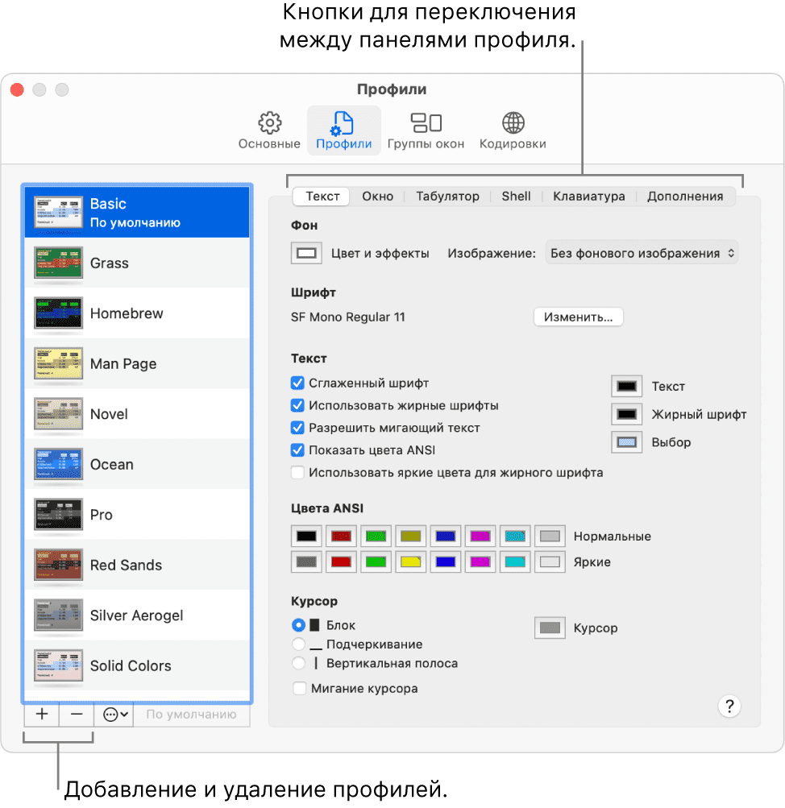

### Создание нового профиля и изменение существующего профиля

1. Откройте приложение «Терминал» на Mac.
2. Выберите «Терминал» > «Настройки», затем нажмите «Профили».
3. Выполните одно из следующих действий:
- Создание нового профиля. Нажмите + кнопку «Добавить» под списком профилей, затем введите название нового профиля.
- Изменение существующего профиля. Выберите профиль, который хотите изменить.
4. Выбор настроек профиля.
- [Текст](https://support.apple.com/ru-ru/guide/terminal/trmltxt/2.14/mac/15.0). Изменение цветов, шрифтов, текста, фонов и стиля курсора.
- [Окно](https://support.apple.com/ru-ru/guide/terminal/trmlwindw/2.14/mac/15.0). Изменение параметров отображения окна, в том числе заголовка, размера и буфера прокрутки.
- [Табулятор](https://support.apple.com/ru-ru/guide/terminal/trmltab/2.14/mac/15.0). Изменение параметров отображения табулятора, в том числе заголовка и имени процесса.
- [Shell](https://support.apple.com/ru-ru/guide/terminal/trmlshll/2.14/mac/15.0). Изменение параметров поведения при загрузке и выходе.
- [Клавиатура](https://support.apple.com/ru-ru/guide/terminal/trmlkbrd/2.14/mac/15.0). Изменение настроек функциональных клавиш, клавиши Option и альтернативного экрана.
- [Дополнения](https://support.apple.com/ru-ru/guide/terminal/trmladvn/2.14/mac/15.0). Изменение типа терминала (terminfo), параметров входа, колокола и региональных кодировок.

### Переименование профиля

1. Откройте приложение «Терминал» на Mac.
2. Выберите «Терминал» > «Настройки», затем нажмите «Профили».
3. Дважды нажмите имя профиля, который хотите переименовать.
4. Введите новое имя и нажмите клавишу Return.

### Создание копии профиля

1. Откройте приложение «Терминал» на Mac.
2. Выберите «Терминал» > «Настройки», затем нажмите «Профили».
3. Выберите профиль, который хотите скопировать.
4. Нажмите (...) всплывающее меню действия, затем выберите «Дублировать профиль».
5. Введите имя копии профиля, затем нажмите клавишу Return.

### Удаление профиля

1. Откройте приложение «Терминал» на Mac.
2. Выберите «Терминал» > «Настройки», затем нажмите «Профили».
3. Выберите профиль, который хотите удалить.
4. Нажмите "-" кнопки «Удалить» под списком профилей.

### Восстановление стандартных профилей Терминала

Если Вы удалили или изменили какие-либо стандартные профили Терминала, Вы можете вернуть их в список профилей с исходными настройками. Набор стандартных профилей можно восстановить только полностью (нельзя восстановить отдельные профили).

Если Вы изменили один из стандартных профилей и хотите сохранить свои настройки, необходимо переименовать этот профиль, прежде чем восстанавливать стандартные профили. При восстановлении перезаписываются все настройки каждого из стандартных профилей.

1. Откройте приложение «Терминал» на Mac.
2. Выберите «Терминал» > «Настройки», затем нажмите «Профили».
3. Нажмите (...) всплывающее меню действия, затем выберите «Профили по умолчанию».

См. также

[Выбор профиля по умолчанию и загрузочного профиля окна Терминала на Mac](https://support.apple.com/ru-ru/guide/terminal/trml5856b1f2/2.14/mac/15.0)

# Выбор профиля по умолчанию и загрузочного профиля окна Терминала на Mac

[URL](https://support.apple.com/ru-ru/guide/terminal/trml5856b1f2/mac)

Можно указать загрузочный профиль и профиль по умолчанию. Загрузочный профиль используется для первого окна, которое Вы видите при открытии Терминала. Профиль по умолчанию используется при открытии дополнительных окон. Один и тот же профиль можно использовать в качестве загрузочного профиля и профиля по умолчанию.

### Выбор загрузочного профиля

1. Откройте приложение «Терминал» на Mac.
2. Выберите «Терминал» > «Настройки», затем нажмите «Основные».
3. Рядом с пунктом «При загрузке» выберите «Новое окно с профилем».
4. Нажмите всплывающее меню, затем выберите имя профиля, который хотите использовать в качестве загрузочного профиля.

Теперь под именем выбранного профиля в панели «Профили» отображается надпись «Загрузка».

### Выбор профиля по умолчанию

1. Откройте приложение «Терминал» на Mac.
2. Выберите «Терминал» > «Настройки», затем нажмите «Профили».
3. Выберите профиль, который хотите использовать в качестве профиля по умолчанию.
4. Нажмите кнопку «По умолчанию» под списком профилей.

Теперь под именем выбранного профиля в панели «Профили» отображается надпись «По умолчанию».

См. также

[Использование профилей для изменения внешнего вида окон Терминала на Mac](https://support.apple.com/ru-ru/guide/terminal/trml107/2.14/mac/15.0)

[Открытие новых окон и вкладок Терминала на Mac](https://support.apple.com/ru-ru/guide/terminal/trmlb20c7888/2.14/mac/15.0)

[Изменение настроек раздела «Основные» в Терминале на Mac](https://support.apple.com/ru-ru/guide/terminal/trmlstrtup/2.14/mac/15.0)

# Настройка звуковых и визуальных предупреждений в Терминале на Mac

[URL](https://support.apple.com/ru-ru/guide/terminal/trml20912/mac)

Некоторые сообщения и команды выдают предупреждения в Терминале. Можно выбрать визуальное (мигание окна Терминала) или звуковое предупреждение.

1. Откройте приложение «Терминал» на Mac.
2. Выберите «Терминал» > «Настройки», затем нажмите «Профили».
3. В списке профилей слева выберите профиль.
4. Нажмите «Дополнения».
5. В разделе «Колокол» выберите тип предупреждения.

См. также

[Использование профилей для изменения внешнего вида окон Терминала на Mac](https://support.apple.com/ru-ru/guide/terminal/trml107/2.14/mac/15.0)

[Изменение дополнительных настроек профиля в Терминале на Mac](https://support.apple.com/ru-ru/guide/terminal/trmladvn/2.14/mac/15.0)

[Если при вводе текста в Терминале на Mac раздается сигнал](https://support.apple.com/ru-ru/guide/terminal/trml35615/2.14/mac/15.0)

# Ограничение количества строк в буфере прокрутки в Терминале на Mac

[URL](https://support.apple.com/ru-ru/guide/terminal/trml15233/mac)

Приложение «Терминал» ведет журнал, который позволяет вернуться к любой строке, введенной пользователем. Однако по мере накопления информации обратная прокрутка содержимого может стать затруднительной.

В настройках Терминала можно изменить количество сохраняемых строк.

1. Откройте приложение «Терминал» на Mac.
2. Выберите «Терминал» > «Настройки», затем нажмите «Профили».
3. В списке профилей слева выберите профиль.
4. Нажмите «Окно».
5. В разделе «Прокрутка вниз» выберите «Ограничить количество строк до», затем введите количество строк.

См. также

[Использование профилей для изменения внешнего вида окон Терминала на Mac](https://support.apple.com/ru-ru/guide/terminal/trml107/2.14/mac/15.0)

[Изменение настроек окна для профиля в Терминале на Mac](https://support.apple.com/ru-ru/guide/terminal/trmlwindw/2.14/mac/15.0)

# Импорт и экспорт профилей Терминала на Mac

[URL](https://support.apple.com/ru-ru/guide/terminal/trml4299c696/mac)

Если Вы хотите перенести профили Терминала между компьютерами, их можно экспортировать и импортировать. Экспортированные файлы имеют расширение «.terminal».

### Импорт профиля

1. Откройте приложение «Терминал» на Mac.
2. Выберите «Терминал» > «Настройки», затем нажмите «Профили».
3. Выполните одно из следующих действий:
- Нажмите (...) всплывающее меню действия, выберите «Импортировать», выберите файл профиля и нажмите «Открыть».
- Перетяните файл профиля из Finder в список профилей.

### Экспорт профиля

1. Откройте приложение «Терминал» на Mac.
2. Выберите «Терминал» > «Настройки», затем нажмите «Профили».
3. Выполните одно из следующих действий:
- Выберите профиль, который нужно экспортировать, нажмите всплывающее меню действия, выберите «Экспортировать», введите имя файла и нажмите «Сохранить».
- Перетяните профиль из списка профилей в окно Finder.

См. также

[Использование профилей для изменения внешнего вида окон Терминала на Mac](https://support.apple.com/ru-ru/guide/terminal/trml107/2.14/mac/15.0)

# Использование автоматизации задач и скриптов

- Основные сведения o shell-скриптах
- Превращение файла в исполняемый файл
- Управление скриптами с помощью команды launchd
- Автоматизация задач с помощью AppleScript и Терминала

# Основные сведения о shell-скриптах в Терминале на Mac

[URL](https://support.apple.com/ru-ru/guide/terminal/apd53500956-7c5b-496b-a362-2845f2aab4bc/mac)

Вместо ввода команд и ожидания ответа Вы можете составить shell-скрипт, который будет выполняться без Вашего непосредственного участия.

Shell-скрипт — это текстовый файл, который содержит одну или несколько команд UNIX. Вместо того чтобы вручную поочередно вводить команды в командной строке, Вы запускаете shell-скрипт, который выполняет все эти команды.

Плюс в том, что в одном shell-скрипте можно объединить большое количество стандартных задач. Это обеспечивает экономию Вашего времени и сокращает количество возможных ошибок при многократном выполнении однотипных задач. Кроме того, shell-скрипты можно автоматизировать с помощью таких инструментов, как launchd или Apple Remote Desktop.

Shell-скрипт начинается с комбинации символов, которая сообщает, что это shell-скрипт. Это символы # и ! (вместе называемые shebang), после которых указывается оболочка shell, в которой должен быть выполнен скрипт. Например, вот первая строка shell-скрипта, который будет запущен в sh:

```
#!/bin/sh
```

Рекомендуется снабжать shell-скрипты комментариями. Чтобы добавить комментарий, начните строку со знака номера (#). Каждая строка комментария должна начинаться со знака номера:

```
#This program returns the
#contents of my Home folder
```

Чтобы визуально отделить различные части shell-скрипта, в него можно добавлять пустые строки.

С помощью инструмента chmod можно указать, что файл является исполняемым (то есть, его содержимое может быть запущено как приложение). См. раздел [Преобразование файлов в исполняемые в Терминале](https://support.apple.com/ru-ru/guide/terminal/apdd100908f-06b3-4e63-8a87-32e71241bab4/2.14/mac/15.0).

Инструкции по написанию shell-скриптов см. в статье [Основные сведения о shell-скриптах](https://developer.apple.com/library/mac/#documentation/OpenSource/Conceptual/ShellScripting) на веб‑сайте Apple для разработчиков.

См. также

[Статья службы поддержки Apple: использование оболочки zsh в качестве стандартной оболочки на компьютере Mac](https://support.apple.com/102360)

# Превращение файлов в исполняемые в команде «Терминал» на Mac

[URL](https://support.apple.com/ru-ru/guide/terminal/apdd100908f-06b3-4e63-8a87-32e71241bab4/mac)

1. Откройте приложение «Терминал» на Mac.
2. Используйте команду cd для перехода к каталогу, содержащему файл, который Вы хотите сделать исполняемым. Например:

   % cd YourScriptDirectory
3. Введите команду chmod. Например:

   % chmod 755 YourScriptName.sh

Сделав файл shell-скрипта исполняемым, Вы можете его запускать, указав путь к файлу. Например:

```
% ~/Documents/Dev/YourScriptName.sh
```

или

```
% cd ~/Documents/Dev/
% ./YourScriptName.sh
```

См. также

[Основные сведения о shell-скриптах в Терминале на Mac](https://support.apple.com/ru-ru/guide/terminal/apd53500956-7c5b-496b-a362-2845f2aab4bc/2.14/mac/15.0)

[Управление скриптами с помощью команды launchd в Терминале на Mac](https://support.apple.com/ru-ru/guide/terminal/apdc6c1077b-5d5d-4d35-9c19-60f2397b2369/2.14/mac/15.0)

[Статья службы поддержки Apple: Использование оболочки zsh в качестве оболочки по умолчанию на компьютере Mac](https://support.apple.com/102360)

```
man chmod
man cd
```

# Управление скриптами с помощью команды launchd в Терминале на Mac

[URL](https://support.apple.com/ru-ru/guide/terminal/apdc6c1077b-5d5d-4d35-9c19-60f2397b2369/mac)

launchd — это первый процесс, запускаемый ядром во время загрузки системы для настройки компьютера. Если Вы хотите запускать shell-скрипт как демон, его должен запускать процесс launchd. Другие способы запуска демонов и агентов подлежат удалению на усмотрение компании Apple.

Чтобы получить общее представление о различных демонах и агентах, управляемых launchd, см. файлы конфигурации, расположенные в следующих папках.

| Папка | Назначение |
| --- | --- |
| /Система/Библиотека/LaunchDaemons | Системные демоны компании Apple |
| /Система/Библиотека/LaunchAgents | Агенты компании Apple, применяемые ко всем пользователям по отдельности |
| /Библиотека/LaunchDaemons | Системные демоны сторонних разработчиков |
| /Библиотека/LaunchAgents | Агенты сторонних разработчиков, применяемые ко всем пользователям по отдельности |
| ~/Библиотека/LaunchAgents | Агенты сторонних разработчиков, применяемые только к текущему пользователю |

См. также

[Основные сведения о shell-скриптах в Терминале на Mac](https://support.apple.com/ru-ru/guide/terminal/apd53500956-7c5b-496b-a362-2845f2aab4bc/2.14/mac/15.0)

[Статья службы поддержки Apple: Использование оболочки zsh в качестве оболочки по умолчанию на компьютере Mac](https://support.apple.com/102360)

[Сайт Apple для разработчиков: Руководство по программированию демонов и служб (на английском языке)](https://developer.apple.com/library/content/documentation/MacOSX/Conceptual/BPSystemStartup/Chapters/Introduction.html#//apple_ref/doc/uid/10000172i-SW1-SW1)

```
man‑страница команды launchd.plist
```

# Автоматизация задач с помощью AppleScript и Терминала

[URL](https://support.apple.com/ru-ru/guide/terminal/trml1003/mac)

С помощью скриптов AppleScript можно ускорить работу с Терминалом и автоматизировать часто выполняемые задачи. Приложение «Терминал» поддерживает сценарии и команды AppleScript. Эти команды описаны в словаре AppleScript для Терминала.

### Просмотр словаря AppleScript для Терминала

1. Откройте приложение Finder на Mac.
2. Откройте папку /Программы/Утилиты.
3. Перетяните значок Терминала на значок Редактора скриптов .

В AppleScript можно использовать команду Do Shell Script для отправки команды сценария UNIX shell в Терминал.

### Запуск скриптов AppleScript с помощью Терминала

Из Терминала можно запускать скрипты AppleScript, используя команду

```
osascript
```

1. Откройте приложение «Терминал» на Mac.
2. Используйте команду cd для перехода к каталогу, содержащему скрипт, который Вы хотите запустить. Например:

   % cd ~/Documents/YourScriptDirectory
3. Введите команду osascript. Например:

   % osascript YourScript.scpt

См. также

[Открытие и завершение приложения «Терминал» на Mac](https://support.apple.com/ru-ru/guide/terminal/apd5265185d-f365-44cb-8b09-71a064a42125/2.14/mac/15.0)

[Выполнение команд и запуск инструментов в приложении «Терминал» на Mac](https://support.apple.com/ru-ru/guide/terminal/apdb66b5242-0d18-49fc-9c47-a2498b7c91d5/2.14/mac/15.0)

[Статья службы поддержки Apple: Использование оболочки zsh в качестве оболочки по умолчанию на компьютере Mac](https://support.apple.com/102360)

# Сочетания клавиш приложения «Терминал» на Mac

[URL](https://support.apple.com/ru-ru/guide/terminal/trmlshtcts/mac)

В приложении «Терминал» на Mac можно быстро выполнять многие действия, используя сочетания клавиш. Сочетания клавиш приведены ниже и в меню приложения «Терминал» в [строке меню](https://support.apple.com/ru-ru/guide/terminal/aside/glos33eb8abd/2.14/mac/15.0). В меню приложения сочетания клавиш [представлены с помощью символов](https://support.apple.com/ru-ru/guide/mac-help/cpmh0011).

Примечание. Сочетания клавиш в приложениях могут зависеть от языка и раскладки клавиатуры, которые используются на Mac. Если приведенные ниже сочетания клавиш работают не так, как ожидалось, посмотрите правильные сочетания в меню приложения в строке меню. Текущую раскладку клавиатуры, также называемую [источником ввода](https://support.apple.com/ru-ru/guide/mac-help/mchlp1015), можно посмотреть в панели «Клавиатура».

### Работа с окнами и вкладками Терминала

| Действие | Сочетание клавиш |
| --- | --- |
| Новое окно | Command-N |
| Новое окно с той же командой | Control-Command-N |
| Новая вкладка | Command-T |
| Новая вкладка с той же командой | Control-Command-T |
| Показать или скрыть панель вкладок | Shift-Command-T |
| Показать все вкладки или выйти из обзора вкладок | Shift-Command-обратная косая черта () |
| Новая команда | Shift-Command-N |
| Новое удаленное подключение | Shift-Command-K |
| Показать или скрыть инспектор | Command-I |
| Править заголовок | Shift-Command-I |
| Изменить цвет фона | Option-Command-I |
| Увеличить шрифты | Command-знак «плюс» (+) |
| Уменьшить шрифты | Command-знак «минус» (–) |
| Следующее окно | Command-обратный апостроф ($`$) |
| Предыдущее окно | Command-Shift-тильда (~) |
| Следующая вкладка | Control-Tab |

| Действие | Сочетание клавиш |
| --- | --- |
| Предыдущая вкладка | Control-Shift-Tab |
| Разделить окно на две панели | Command-D |
| Закрыть панель | Shift-Command-D |
| Закрыть вкладку | Command-W |
| Закрыть окно | Shift-Command-W |
| Закрыть другие вкладки | Option-Command-W |
| Закрыть все | Option-Shift-Command-W |
| Прокрутить вверх | Command-Home |
| Прокрутить вниз | Command-End |
| Страница вверх | Command-Page Up |
| Страница вниз | Command-Page Down |
| Строка вверх | Option-Command-Page Up |
| Строка вниз | Option-Command-Page Down |

# Редактирование командной строки

| Действие | Сочетание клавиш |
| --- | --- |
| Перемещение точки вставки | Переместите курсор в новую точку вставки при нажатой клавише Option. |
| Перемещение точки вставки в начало строки | Control-A |
| Перемещение точки вставки в конец строки | Control-E |
| Перемещение точки вставки на один символ вперед | Стрелка вправо |
| Перемещение точки вставки на один символ назад | Стрелка влево |
| Перемещение точки вставки на одно слово вперед | Option-правая стрелка |
| Перемещение точки вставки на одно слово назад | Option-левая стрелка |
| Удаление строки | Control-U |
| Удаление до конца строки | Control-K |
| Удаление вперед до конца слова | Option-D (доступно при выбранном параметре Использовать клавишу «Option» в качестве мета-клавиши) |
| Удаление назад до начала слова | Control-W |
| Удалить один символ | Delete |
| Удаление одного символа после курсора | Удаление вперед (или используйте сочетание клавиш Fn-Delete) |
| Транспонирование двух символов | Control-T |

### Выбор и поиск текста в окне Терминала

| Действие | Сочетание клавиш |
| --- | --- |
| Выбрать полный путь файла | Дважды нажмите путь к файлу, удерживая клавиши Shift и Command |
| Выбрать всю строку текста | Трижды нажмите строку |
| Выбрать слово | Дважды нажмите слово |

[output not shown]

# Работа с маркерами и закладками

| Действие | Сочетание клавиш |
| --- | --- |
| Маркировать | Command-U |
| Отметить как закладку | Option-Command-U |
| Удалить пометку | Shift-Command-U |
| Отметить строку и отправить символ переноса строки | Command-Return |
| Отправить Return без маркировки | Shift-Command-Return |
| Вставить закладку | Shift-Command-M |
| Вставить закладку с именем | Option-Shift-Command-M |
| Перейти к предыдущему маркеру | Command-стрелка вверх |
| Перейти к следующему маркеру | Command-стрелка вниз |
| Перейти к предыдущей закладке | Option-Command-стрелка вверх |
| Перейти к следующей закладке | Option-Command-стрелка вниз |
| Очистить до предыдущего маркера | Command-L |
| Очистить до предыдущей закладки | Option-Command-L |
| Очистить до начала | Command-K |
| Выбрать область между маркерами | Shift-Command-A |

# Другие сочетания клавиш

| Действие | Сочетание клавиш |
| --- | --- |
| Включить или выключить полноэкранный режим | Control-Command-F |
| Показать или скрыть цвета | Shift-Command-C |
| Открыть настройки Терминала | Command-запятая (,) |
| Break | Ввод точки (.) при нажатой клавише Command равнозначен сочетанию клавиш Control-C в командной строке |
| Напечатать | Command-P |
| Безопасный сброс состояния эмулятора Терминала | Option-Command-R |
| Аппаратный сброс состояния эмулятора Терминала | Control-Option-Command-R |
| Открыть URL | Удерживая клавишу Command, дважды нажмите URL |
| Добавить полный путь к файлу | Перетяните файл из Finder в окно Терминала. |
| Экспортировать текст как | Command-S |
| Экспортировать выбранный текст как | Shift-Command-S |
| Поиск по истории команд в обратном направлении | Control-R |
| Переключить параметр «Разрешить отчеты об использовании мыши» | Command-R |
| Переключить параметр «Использовать клавишу Option как метаклавишу» | Command-Option-O |
| Показать альтернативный экран | Shift-Command-стрелка вниз |
| Скрыть альтернативный экран | Shift-Command-стрелка вверх |
| Открыть man-страницу для выбранного | Control-Shift-Command-знак вопроса (?) |
| Искать выбранное в указателе man-страницы | Control-Option-Command-косая черта (/) |
| Завершить имя каталога или файла | Введите один или несколько символов в командной строке, затем нажмите Tab |
| Отобразить список возможных вариантов завершения имени каталога или файла | Введите один или несколько символов в командной строке, затем дважды нажмите Tab |

См. также

[Создание собственных функциональных клавиш в Терминале на Mac](https://support.apple.com/ru-ru/guide/terminal/trml108/2.14/mac/15.0)

[Изменение настроек клавиатуры для профиля в Терминале на Mac](https://support.apple.com/ru-ru/guide/terminal/trmlkbrd/2.14/mac/15.0)

[Статья службы поддержки Apple: Сочетания клавиш Mac](https://support.apple.com/102650)

# Авторские права

[URL](https://support.apple.com/ru-ru/guide/terminal/apd2185d6ee5/mac)